## Course: COMPUTATIONAL THINKING FOR GOVERNANCE ANALYTICS

### Prof. José Manuel Magallanes, PhD

- Visiting Professor of Computational Policy at Evans School of Public Policy and Governance, and eScience Institute Senior Data Science Fellow, University of Washington.
- Professor of Government and Political Methodology, Pontificia Universidad Católica del Perú.

# Session 5: Intro to R (II)

Collect the data we prepared in Python:

```r
link='https://github.com/UWDataScience2020/data/raw/master/hdidemocia.RDS'
# a RDS file from the web needs:
myFile=url(link)

# reading in data:
fromPy=readRDS(file = myFile)

# reset indexes to R format:
row.names(fromPy)=NULL
```

# Unsupervised ML: Clustering Techniques

1. Partitioning: You will request a particular number of clusters to the algorithm. The algorithm will put every case in one of those clusters. Outliers will affect output.

[figure not shown]

Source: https://en.wikipedia.org/wiki/Cluster_analysis

2. Hierarchizing: You will ask the algorithm to find all possible ways cases can be clustered, individually and in subgroups following a tree-construction/deconstruction approach. You should determine the right amount of clusters.Outliers will affect output.

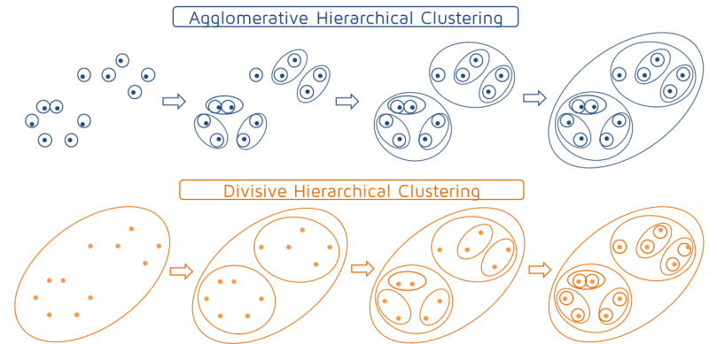

Source: https://quantdare.com/hierarchical-clustering/

3. Based on Density

This approach will cluster cases as long as they are close to each other at a predetermined distance. You need to input the distance and the minimal amount of cases in a neighboorhood to be considered a cluster. The algorithm is not affected by outliers.

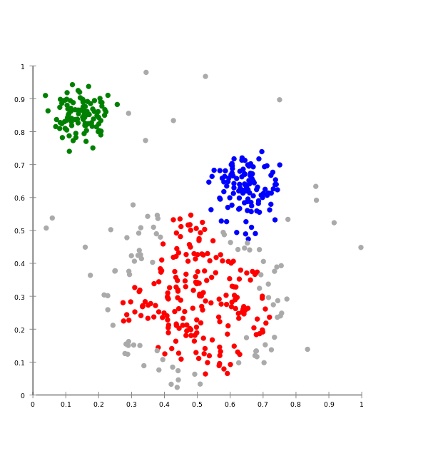

https://commons.wikimedia.org/wiki/Cluster_analysis

## Preparing data:

For all cases, you need the DISTANCE MATRIX:

**a.** Explore variables you will used for clustering

```r
str(fromPy[,c(2,13,16)])
```

```
## 'data.frame':    164 obs. of  3 variables:
##  $ Humandevelopmentindex: num  0.954 0.946 0.942 0.939 0.939 0.938 0.938 0.937 0.935 0.933 ...
##  $ Regimetype           : Ord.factor w/ 4 levels "Authoritarian"<..: 4 4 4 4 3 4 4 4 3 4 ...
##  $ co2_in_MT            : num  3.98e+07 3.90e+07 3.69e+07 8.48e+08 1.02e+08 ...
```

**b.** Rescale units if needed into a new variable:

```r
fromPy$co2_in_millionMT=fromPy$co2_in_MT/10^6
```

**c.** Subset the data frame:

```r
dfClus=fromPy[,c(2,13,17)]
```

**d.** Rename subset indexes and Verify what your input is:

```r
row.names(dfClus)=fromPy$Country
head(dfClus)
```

```
##             Humandevelopmentindex       Regimetype co2_in_millionMT
## Norway                      0.954   Full democracy            39.80
## Switzerland                 0.946   Full democracy            38.95
## Ireland                     0.942   Full democracy            36.91
## Germany                     0.939   Full democracy           847.60
## Hong Kong                   0.939 Flawed democracy           102.50
## Australia                   0.938   Full democracy           439.10
```

**e.** Set random seed:

```r
set.seed(999) # this is for replicability of results
```

**f.** Decide distance method and compute distance matrix:

```r
library(cluster)
dfClus_D=cluster::daisy(x=dfClus,metric="gower")
```

## Partitioning technique

### 1. Apply function: you need to indicate the amount of clusters required.

```r
NumCluster=4
res.pam = pam(x=dfClus_D,k = NumCluster,cluster.only = F)
```

### 2. Clustering results.

**2.1** Add results to original data frame:

```r
fromPy$pam=as.factor(res.pam$clustering)
```

**2.2** Query data frame as needed:

Example 1:

```r
fromPy[fromPy$pam==1,'Country']
```

```
##  [1] "Norway"         "Switzerland"    "Ireland"        "Germany"
##  [5] "Australia"      "Iceland"        "Sweden"         "Netherlands"
##  [9] "Denmark"        "Finland"        "Canada"         "New Zealand"
## [13] "United Kingdom" "Austria"        "Luxembourg"     "Spain"
## [17] "France"         "Portugal"       "Chile"          "Uruguay"
## [21] "Mauritius"      "Costa Rica"
```

Example 2:

```r
fromPy[fromPy$Country=="Peru",'pam']
```

```
## [1] 2
## Levels: 1 2 3 4
```

**2.2** REPORT: Table of clusters

```r
table(fromPy$pam)
```

```
##
##  1  2  3  4
## 22 54 52 36
```

### 3. Evaluate Results.

**3.1** REPORT: Average silhouettes

```r
library(factoextra)
```

```
##   cluster size ave.sil.width
## 1       1   22          0.81
## 2       2   54          0.49
## 3       3   52          0.47
## 4       4   36          0.53
```

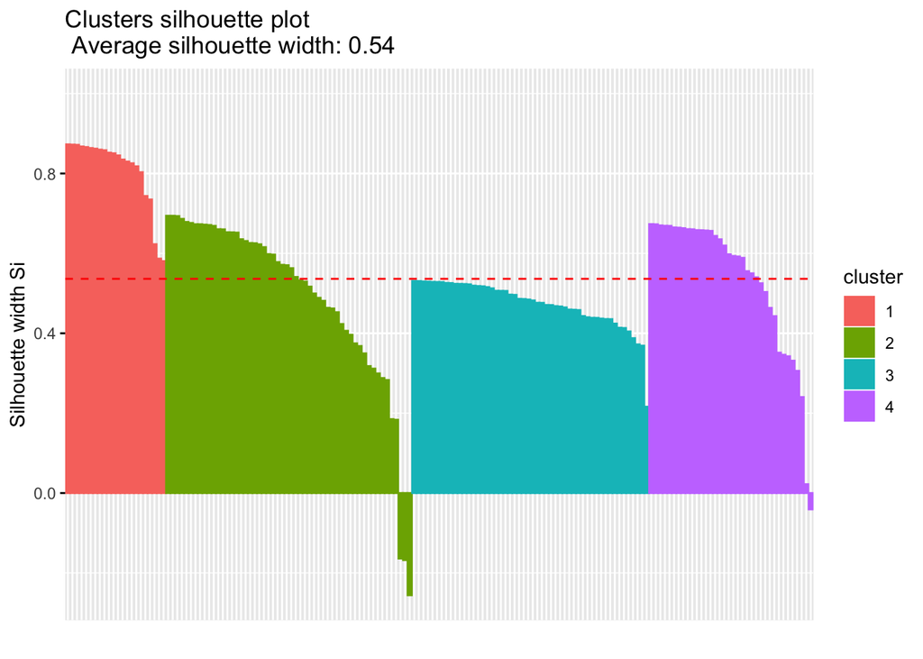

```r
fviz_silhouette(res.pam)
```

**3.2** REPORT: Detecting anomalies

1. Save individual silhouettes:

```r
pamEval=data.frame(res.pam$silinfo$widths)
head(pamEval)
```

```
##             cluster neighbor sil_width
## Finland           1        2 0.8729713
## New Zealand       1        2 0.8722811
## Denmark           1        2 0.8717713
## Sweden            1        2 0.8676382
## Austria           1        2 0.8662296
## Iceland           1        2 0.8637618
```

2. Request negative silhouettes:

```r
pamEval[pamEval$sil_width<0,]
```

```
##                  cluster neighbor   sil_width
## Turkey                 2        4 -0.16389921
## Montenegro             2        4 -0.16780333
## Albania                2        4 -0.25575833
## Papua New Guinea       4        2 -0.04088538
```

## Hierarchizing: agglomerative

### 1. Apply function: you need to indicate the amount of clusters required.

```r
library(factoextra)

res.agnes= hcut(dfClus_D, k = NumCluster,isdiss=T,
                 hc_func='agnes',
                 hc_method = "ward.D2")
```

### 2. Clustering results.

**2.1** Add results to original data frame:

```r
fromPy$agn=as.factor(res.agnes$cluster)
```

**2.2** Query data frame as needed:

Example 1:

```r
fromPy[fromPy$agn==1,'Country']
```

```
##  [1] "Norway"         "Switzerland"    "Ireland"        "Germany"
##  [5] "Australia"      "Iceland"        "Sweden"         "Netherlands"
##  [9] "Denmark"        "Finland"        "Canada"         "New Zealand"
## [13] "United Kingdom" "Austria"        "Luxembourg"     "Spain"
## [17] "France"         "Portugal"       "Chile"          "Uruguay"
## [21] "Mauritius"      "Costa Rica"
```

Example 2:

```r
fromPy[fromPy$Country=="Peru",'agn']
```

```
## [1] 2
## Levels: 1 2 3 4
```

**2.2** REPORT: Table of clusters

Reporting results:

```r
table(fromPy$agn)
```

```
##
##  1  2  3  4
## 22 53 52 37
```

### 3. Evaluate Results.

**3.1a** REPORT: Dendogram

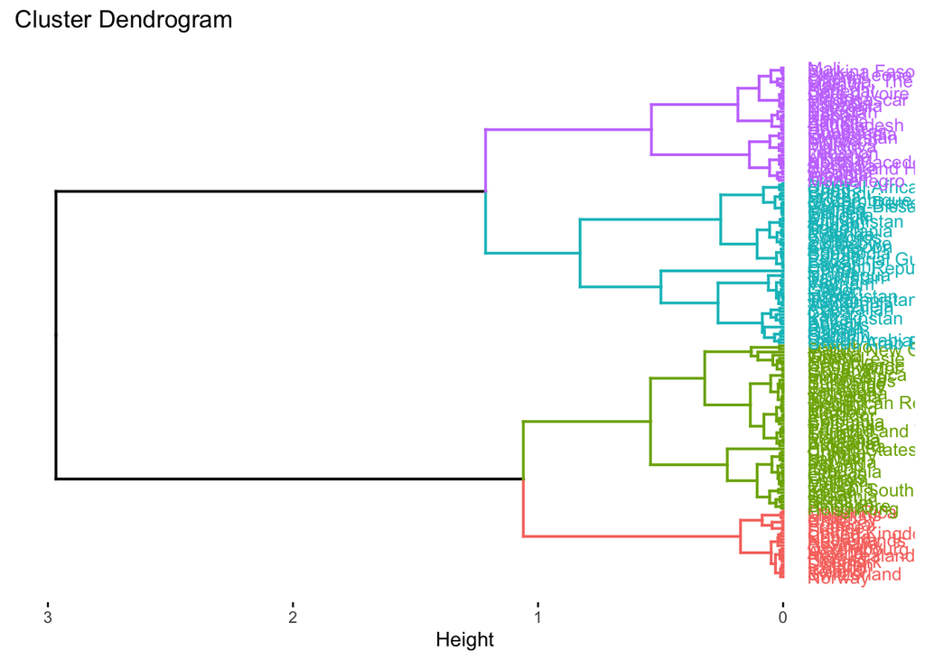

```r
fviz_dend(res.agnes,k=NumCluster, cex = 0.7, horiz = T)
```

**3.1b** REPORT: Average silhouettes:

```
##   cluster size ave.sil.width
## 1       1   22          0.81
## 2       2   53          0.53
## 3       3   52          0.47
## 4       4   37          0.56
```

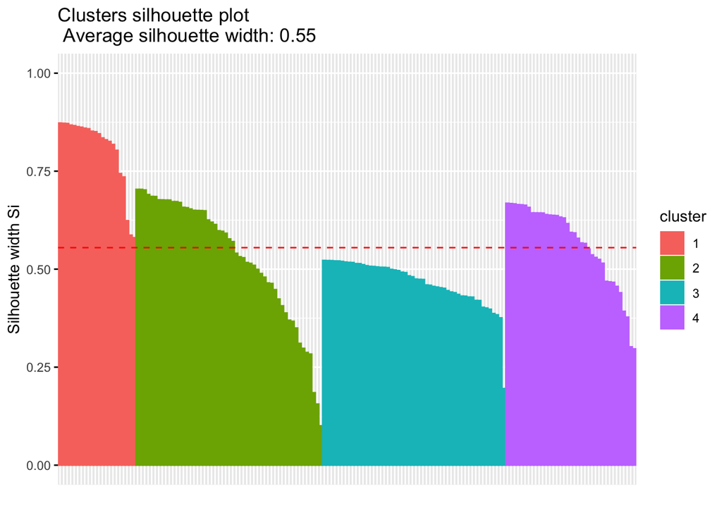

```r
library(factoextra)
fviz_silhouette(res.agnes)
```

**3.2** REPORT: Detecting anomalies

1. Saving silhouettes:

```r
agnEval=data.frame(res.agnes$silinfo$widths)
head(agnEval)
```

```
##             cluster neighbor sil_width
## Finland           1        2 0.8728906
## New Zealand       1        2 0.8721984
## Denmark           1        2 0.8716856
## Sweden            1        2 0.8675533
## Austria           1        2 0.8661589
## Iceland           1        2 0.8636620
```

2. Requesting negative silhouettes:

```r
agnEval[agnEval$sil_width<0,]
```

```
## [1] cluster   neighbor  sil_width
## <0 rows> (or 0-length row.names)
```

## Hierarchizing: divisive

### 1. Apply function: you need to indicate the amount of clusters required.

```r
library(factoextra)

res.diana= hcut(dfClus_D, k = NumCluster,
                 hc_func='diana',
                 hc_method = "ward.D")
```

### 2. Clustering results.

**2.1** Add results to original data frame:

```r
fromPy$dia=as.factor(res.diana$cluster)
```

**2.2** Query data frame as needed:

Example 1:

```r
fromPy[fromPy$dia==1,'Country']
```

```
##  [1] "Norway"              "Switzerland"         "Ireland"
##  [4] "Germany"             "Hong Kong"           "Australia"
##  [7] "Iceland"             "Sweden"              "Singapore"
## [10] "Netherlands"         "Denmark"             "Finland"
## [13] "Canada"              "New Zealand"         "United Kingdom"
## [16] "United States"       "Belgium"             "Japan"
## [19] "Austria"             "Luxembourg"          "Israel"
## [22] "Korea, South"        "Slovenia"            "Spain"
## [25] "Czechia"             "France"              "Malta"
## [28] "Italy"               "Estonia"             "Cyprus"
## [31] "Greece"              "Poland"              "Lithuania"
## [34] "Slovakia"            "Latvia"              "Portugal"
## [37] "Chile"               "Hungary"             "Croatia"
## [40] "Argentina"           "Bulgaria"            "Romania"
## [43] "Uruguay"             "Malaysia"            "Serbia"
## [46] "Trinidad and Tobago" "Mauritius"           "Panama"
## [49] "Costa Rica"          "Sri Lanka"           "Mexico"
## [52] "Thailand"            "Brazil"              "Colombia"
## [55] "Peru"                "Ecuador"             "Dominican Republic"
## [58] "Tunisia"             "Mongolia"            "Botswana"
## [61] "Jamaica"             "Paraguay"            "Suriname"
## [64] "Philippines"         "Indonesia"           "South Africa"
## [67] "Guyana"              "El Salvador"         "Cabo Verde"
## [70] "India"               "Namibia"             "Timor-Leste"
## [73] "Ghana"               "Papua New Guinea"    "Lesotho"
```

Example 2:

```r
fromPy[fromPy$Country=="Peru",'dia']
```

```
## [1] 1
## Levels: 1 2 3 4
```

**2.2** REPORT: Table of clusters

Reporting results:

```r
table(fromPy$dia)
```

```
##
##  1  2  3  4
## 75 39  1 49
```

### 3. Evaluate Results.

**3.1a** REPORT: Dendogram

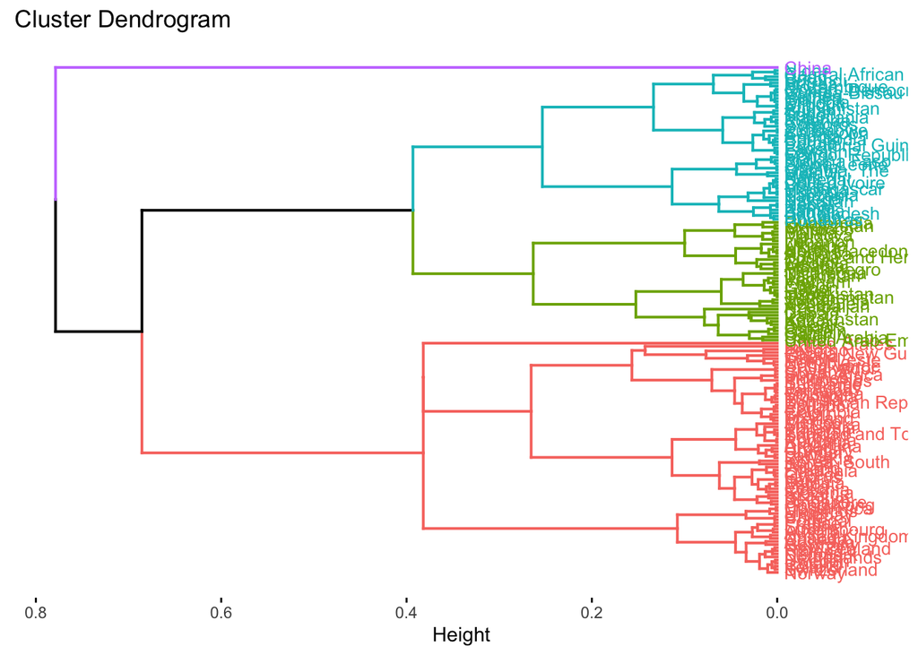

```r
fviz_dend(res.diana,k=NumCluster, cex = 0.7, horiz = T)
```

**3.1b** REPORT: Average silhouettes:

```
##   cluster size ave.sil.width
## 1       1   75          0.54
## 2       2   39          0.45
## 3       3    1          0.00
## 4       4   49          0.47
```

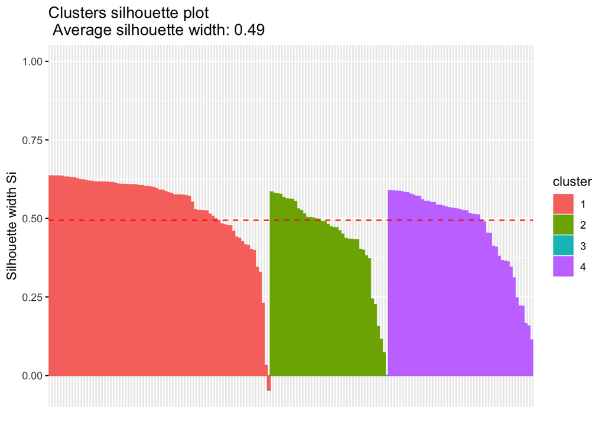

```r
library(factoextra)
fviz_silhouette(res.diana)
```

**3.2** REPORT: Detecting anomalies

1. Saving silhouettes:

```r
diaEval=data.frame(res.diana$silinfo$widths)
head(diaEval)
```

```
##          cluster neighbor sil_width
## Slovenia       1        2 0.6352929
## Israel         1        2 0.6350096
## Czechia        1        2 0.6349339
## Malta          1        2 0.6349004
## Estonia        1        2 0.6341346
## Greece         1        2 0.6315834
```

2. Requesting negative silhouettes:

```r
diaEval[diaEval$sil_width<0,]
```

```
##         cluster neighbor   sil_width
## Lesotho       1        4 -0.04678181
```

## Density-based clustering

You input the distance and the minimal number of neighbors that form a cluster.

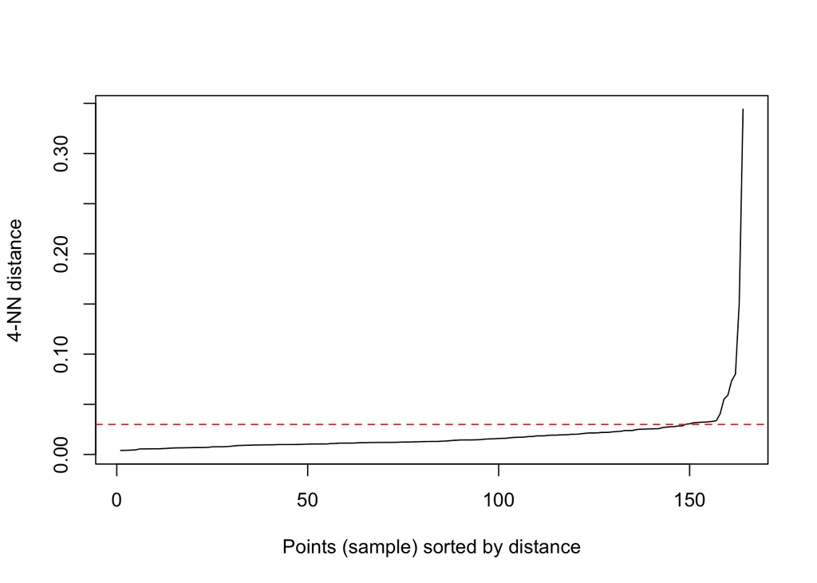

```r
library(dbscan)
#minNeighs> num cols in data
minNeighs=4
kNNdistplot(dfClus_D, k = minNeighs)
abline(h=.03, col = "red", lty=2)
```

```r
distance=0.03
res.db = dbscan::dbscan(dfClus_D, eps=distance,
                     minPts=minNeighs)
```

**REPORT**:

How many cluster were produced? and How many outliers are there?

```r
# '0' identifies outliers:
res.db
```

```
## DBSCAN clustering for 164 objects.
## Parameters: eps = 0.03, minPts = 4
## The clustering contains 5 cluster(s) and 6 noise points.
##
##  0  1  2  3  4  5
##  6 17 49 50 37  5
##
## Available fields: cluster, eps, minPts
```

Save result:

```r
fromPy$db=as.factor(res.db$cluster)
```

# How to compare clustering?

- Prepare a bidimensional map:

```r
projectedData = cmdscale(dfClus_D, k=2)
#
# save coordinates to original data frame:
fromPy$dim1 = projectedData[,1]
fromPy$dim2 = projectedData[,2]
```

- See the “map”:

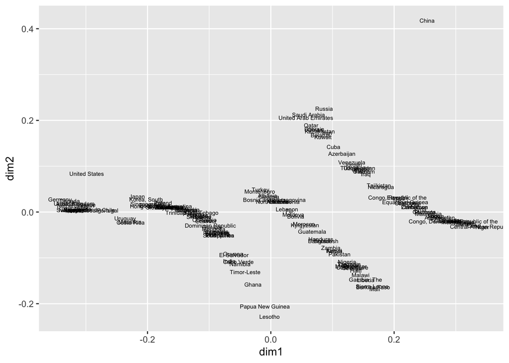

```r
base= ggplot(data=fromPy,
             aes(x=dim1, y=dim2,
                 label=Country))
base + geom_text(size=2)
```

- Plot results from PAM:

```r
pamPlot=base + labs(title = "PAM") + geom_point(size=2,
                                              aes(color=pam),
                                              show.legend = F)
```

- Plot results from Hierarchical AGNES:

```r
agnPlot=base + labs(title = "AGNES") + geom_point(size=2,
                                              aes(color=agn),
                                              show.legend = F)
```

- Plot results from Hierarchical DIANA:

```r
diaPlot=base + labs(title = "DIANA") + geom_point(size=2,
                                              aes(color=dia),
                                              show.legend = F)
```

Compare visually:

```r
library(ggpubr)
```

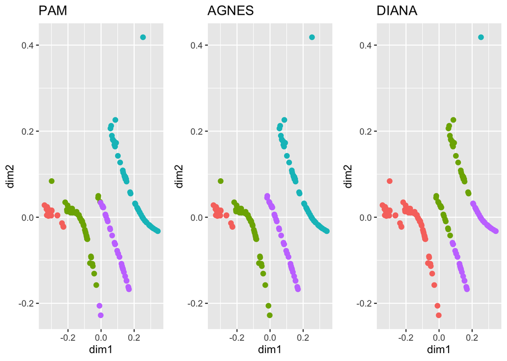

```r
ggarrange(pamPlot, agnPlot, diaPlot,ncol = 3)
```

- Plot results from DBSCAN:

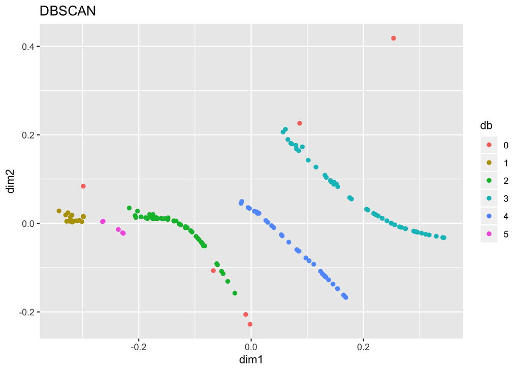

```r
dbPlot= base + labs(title = "DBSCAN") + geom_point(aes(color=db),
                                               show.legend = T)
dbPlot
```

Annotating:

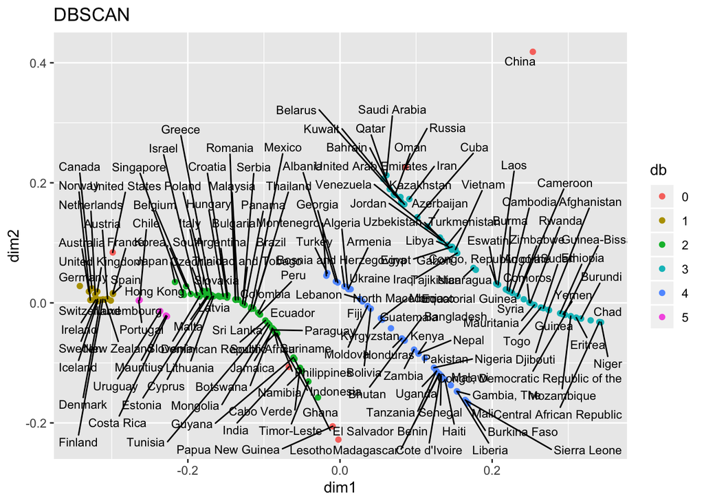

```r
library(ggrepel)
dbPlot + geom_text_repel(size=3,aes(label=Country))
```

Annotating outliers:

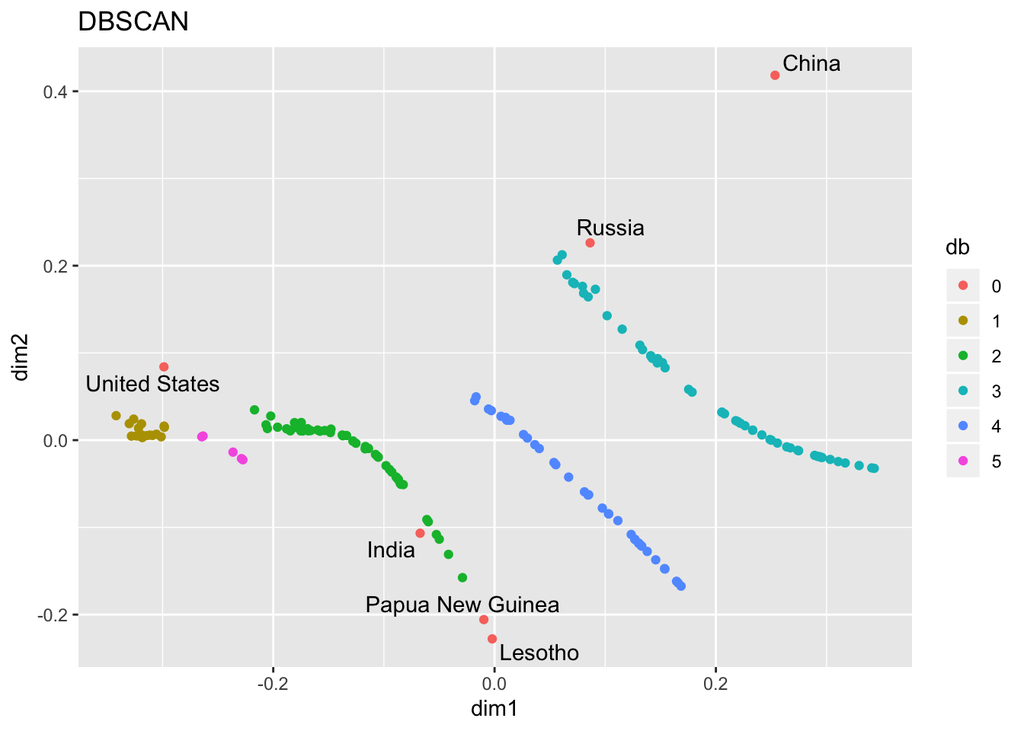

```r
LABEL=ifelse(fromPy$db==0,fromPy$Country,"")

dbPlot + geom_text_repel(aes(label=LABEL))
```

## Exercise 15

- Create a **personal** repo for your project.
- In that repo, save your clean and formatted data.
- Create a code to merge your data with your group mates’ data sets.
- Decide and select one or two variables for each data set.
- Each member of the group will choose/be assigned an algorithm to use (pam, agnes, diana, dbscan).
- Produce the clusters and produce all the **REPORTS** for the technique chosen/assigned to you.